# Rappels de Statistique

FX Jollois

TC - 2ème année - 2021/2022

# Qu’est-ce que la statistique ?

- Ensemble de méthodes permettant de décrire et d’analyser des observations (communément appelées **données** de nos jours)
- Utilisé maintenant dans tous les secteurs d’activités
  - Economie et finance : marketing, sondages…
  - Industrie : fiabilité, contrôle qualité…
  - Santé : recherche médicale, gestion des hôpitaux…
  - Environnement : prévisions climatiques et météorologiques, pollution…
  - Web : réseaux, publicité…
  - …
- Essor important avec le développement des outils informatiques et du web

# Définitions de base

- **Population** : ensemble d’entités (personnes, objets…) étudiés
- **Individu** (ou *unité statistique*) : entité étudié
- **Variable** : caractéristique mesurée sur chaque individu
- **Observation** : mesure
- **Série statistique** : série d’observations recueillies sur les individus
- **Tableau de données** : stockage de la série statistique
  - Individus croisant des variables
  - Chaque ligne représente un individu
  - Chaque colonne représente une variable (ou attribut)
  - C’est ce qu’on fait classiquement dans un tableur de type Excel

# Données *Diamants*

- Exemple utilisé dans ce document
- ~54000 diamants (100 premières lignes ici)

| carat | cut | color | clarity | depth | table | price | x | y | z |
| --- | --- | --- | --- | --- | --- | --- | --- | --- | --- |
| 0.23 | Ideal | E | SI2 | 61.5 | 55 | 326 | 3.95 | 3.98 | 2.43 |
| 0.21 | Premium | E | SI1 | 59.8 | 61 | 326 | 3.89 | 3.84 | 2.31 |
| 0.23 | Good | E | VS1 | 56.9 | 65 | 327 | 4.05 | 4.07 | 2.31 |
| 0.29 | Premium | I | VS2 | 62.4 | 58 | 334 | 4.2 | 4.23 | 2.63 |
| 0.31 | Good | J | SI2 | 63.3 | 58 | 335 | 4.34 | 4.35 | 2.75 |
| 0.24 | Very Good | J | VVS2 | 62.8 | 57 | 336 | 3.94 | 3.96 | 2.48 |
| 0.24 | Very Good | I | VVS1 | 62.3 | 57 | 336 | 3.95 | 3.98 | 2.47 |
| 0.26 | Very Good | H | SI1 | 61.9 | 55 | 337 | 4.07 | 4.11 | 2.53 |
| 0.22 | Fair | E | VS2 | 65.1 | 61 | 337 | 3.87 | 3.78 | 2.49 |
| 0.23 | Very Good | H | VS1 | 59.4 | 61 | 338 | 4 | 4.05 | 2.39 |

[output cut: 90 more lines]

# Recensement vs Sondage

### Recensement

Etude de tous les individus d’une population

- Recueil exhaustif de toutes les informations sur tous les entités
- Difficile à mettre en œuvre la plupart du temps

### Sondage

Etude d’une partie de la population pour extrapolation sur l’ensemble de la population

- Partie des individus étudiés = **échantillon**
- Représentativité de l’échantillon ?

# Type de variables

### Variable quantitative

- Caractéristiques numériques : opérations de type somme ayant un sens
- **Continue** :
  - Mesurable
  - Ex : taille, poids, durée…
- **Discrète** :
  - Dénombrable ou mesurable en espace fini
  - Ex : âge, quantité en stock…

# Type de variables

### Variable qualitative

- Caractéristiques non numériques : opérations de type somme n’ayant pas de sens
  - Valeurs possibles : **Modalités** (ou catégories)
- **Nominale** :
  - Modalités n’ayant pas de lien entre elles
  - Ex : couleur des yeux, sexe…
  - Cas particulier : *binaire*
- **Ordinale** :
  - Modalités devant être triées dans un ordre spécifique
  - Ex : mois, sentiment…

# Transformation de variable

### Quantitative en qualitative

- Courant de transformer une variable **quantitative** en variable **qualitative ordinale**
  - Ex : catégorie d’âge
- Différents problèmes se posent
  - Combien de modalités (*intervalles* ici) ?
  - Taille identique des intervalles ou variable (*amplitude*) ?
  - Seuils des intervalles ?

### Standardisation ou normalisation d’une variable quantitative

# Premier problème : décrire les données

On parle de **Statistique descriptive** ou **exploratoire**

### Objectifs

- Résumer l’information contenue dans les données
- Faire ressortir des éléments intéressants
- Poser des hypothèses sur des phénomènes potentiellement existant dans les données

### Outils

- Description numérique (moyenne, occurrences, corrélation…)
- Description graphique (histogramme, diagramme en barres, nuage de points…)

# Variable quantitative

- Moyenne $\bar{x}$
  $$\bar{x} = \frac{1}{n} \sum_{i=1}^n x_i$$
- Variance (et écart-type $\sigma(x)$)
  $$\sigma^2(x) = \frac{1}{n} \sum_{i=1}^n (x_i - \bar{x})^2$$
- Médiane $med(x)$ : valeur permettant de séparer les valeurs ordonnées prises par $x$ en 2 groupes de même taille
  $$med(x) = m | p(x \le m) = .5$$
  - si $n$ est impair : $med(x) = x_{(n + 1) / 2}$
  - si $n$ est pair : $med(x) = \frac{x_{n/2} + x_{n/2 + 1}}{2}$
- Quantile $q_p(x)$ : valeur pour laquelle une proportion $p$ de valeurs sont inférieures
  $$q_p(x) = q | p(x \le q) = p$$
  - Quartiles $Q1$ et $Q3$ : respectivement 25% et 75% (utilisés dans les boîtes à moustaches)

# Variable quantitative

### Exemple : prix des diamants

### Représentation numérique

| Statistique | Valeur |
| --- | --- |
| Moyenne | 3932.79972191324 |
| Ecart-Type | 3989.43973814638 |
| Variance | 15915629.4243014 |
| Médiane | 2401 |
| Minimum | 326 |
| Maximum | 18823 |

A regarder aussi :

- Divergence moyenne et médiane
  - Valeurs extrêmes présentes
  - Déséquilibre de la répartition des valeurs
- Présence de valeurs aberrantes
  - On parle d’**outliers**

### Représentation graphique

Histogramme et boîte à moustaches

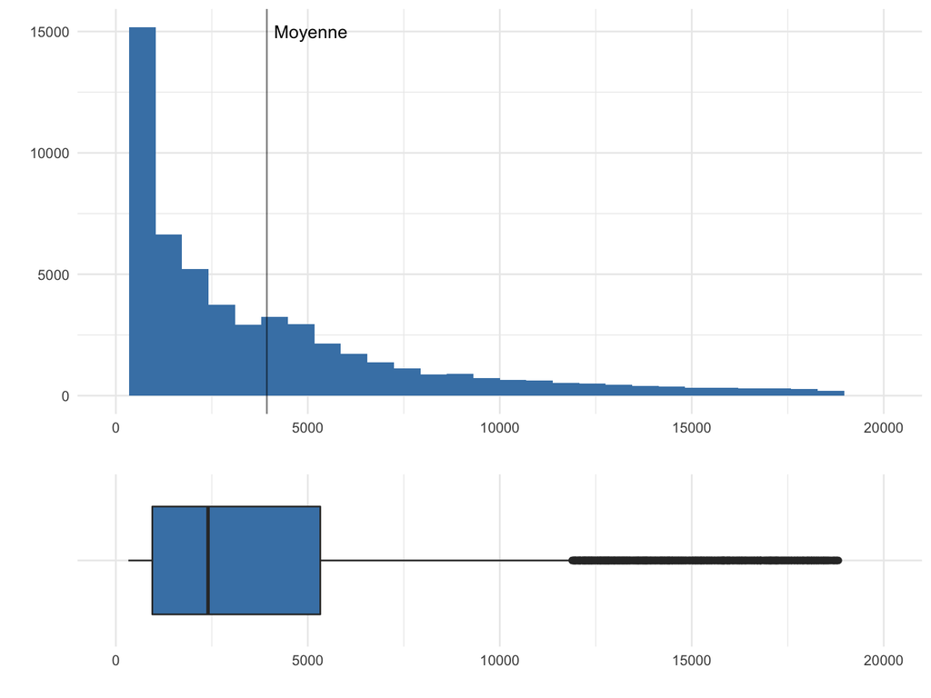

# Variable qualitative

### Nominale

- Modalités de la variable $x$ : $m_j$ (avec $j=1,\ldots,p$)
- Effectif (ou occurrences) d’une modalité $n_j$ : nombre d’individus ayant la modalité $m_j$
- Fréquence d’une modalité $f_j$
  $$f_j = \frac{n_j}{n}$$

### Ordinale

- Effectif cumulé $n_j^{cum}$ : nombre d’individus ayant une modalité entre $n_1$ et $n_j$
  $$n_j^{cum} = \sum_{k=1}^j n_k$$
- Fréquence cumulée
  $$f_j^{cum} = \sum_{k=1}^j f_k$$

# Variable qualitative

### Exemple : Qualité de découpe (*ordinale* de plus)

### Représentation numérique

| Modalités | Effectifs | Effectifs cumulés | Fréquences | Fréquences cumulées |
| --- | --- | --- | --- | --- |
| Fair | 1610 | 1610 | 0.0298479792361884 | 0.0298479792361884 |
| Good | 4906 | 6516 | 0.0909529106414535 | 0.120800889877642 |
| Very Good | 12082 | 18598 | 0.223989618094179 | 0.344790507971821 |
| Premium | 13791 | 32389 | 0.25567296996663 | 0.60046347793845 |
| Ideal | 21551 | 53940 | 0.39953652206155 | 1 |

A regarder aussi :

- Différence entre les proportions
- Si modalités peu fréquentes, regroupement de modalités à envisager
  - Attention au sens de ces regroupements

### Représentation graphique

Diagramme en barres

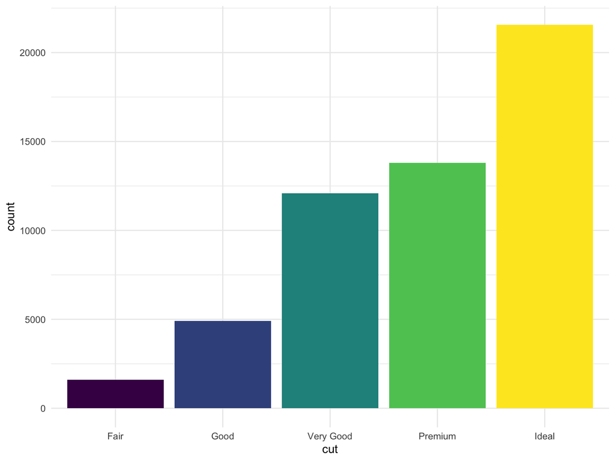

# Quantitative vs quantitative

# Quantitative vs quantitative

### Exemple : Prix et Carat

### Représentation numérique

| Statistique | Valeur |
| --- | --- |
| Covariance | 1742.76536426512 |
| Corrélation | 0.921591301193477 |

A regarder aussi :

- Présence d’**outliers** avec un comportement atypique

### Représentation graphique

Nuage de points

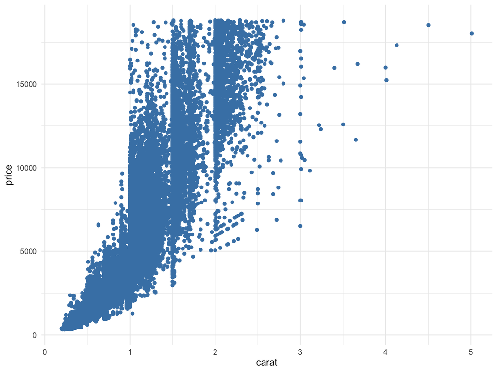

# Anscombe

La visualisation est aussi importante (voire plus) que la représentation numérique !

Entre ces quatres séries :

- même moyenne et même variance pour $x$ et $y$
- même coefficient de corrélation entre les deux

[output not shown]

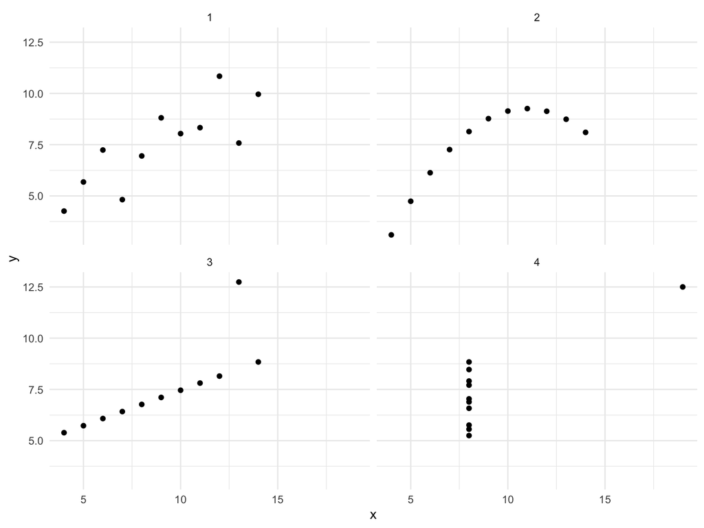

# Qualitative vs qualitative

- Table de contingence
  - Croisement des 2 ensembles de modalités, avec le nombre d’individus ayant chaque couple de modalités
  - $n_{ij}$ : Nombre d’observations ayant la modalité $i$ pour $x$ et $j$ pour $y$
  - $n_{i.}$ : Effectif marginal (nombre d’observations ayant la modalité $i$ pour $x$)
  - $n_{.j}$ : Effectif marginal (nombre d’observations ayant la modalité $j$ pour $y$)
- Profils lignes et colonnes
  - Distribution d’une variable conditionnellement aux modalités de l’autre

|  | 1 | ... | j | ... | l | total |
| --- | --- | --- | --- | --- | --- | --- |
| 1 |  |  |  |  |  |  |
| ... |  |  |  |  |  |  |
| i |  |  | n_ij |  |  | n_i. |
| ... |  |  |  |  |  |  |
| k |  |  |  |  |  |  |
| total |  |  | n_.j |  |  | n_.. = n |

# Qualitative vs qualitative

### Exemple : Qualité et couleur

### Représentation numérique

| color | Fair | Good | Very Good | Premium | Ideal |
| --- | --- | --- | --- | --- | --- |
| D | 163 | 662 | 1513 | 1603 | 2834 |
| E | 224 | 933 | 2400 | 2337 | 3903 |
| F | 312 | 909 | 2164 | 2331 | 3826 |
| G | 314 | 871 | 2299 | 2924 | 4884 |
| H | 303 | 702 | 1824 | 2360 | 3115 |
| I | 175 | 522 | 1204 | 1428 | 2093 |
| J | 119 | 307 | 678 | 808 | 896 |

A regarder aussi :

- Couple de modalités très peu pris
- Ici aussi, regroupement de modalités à envisager éventuellement

### Représentation graphique

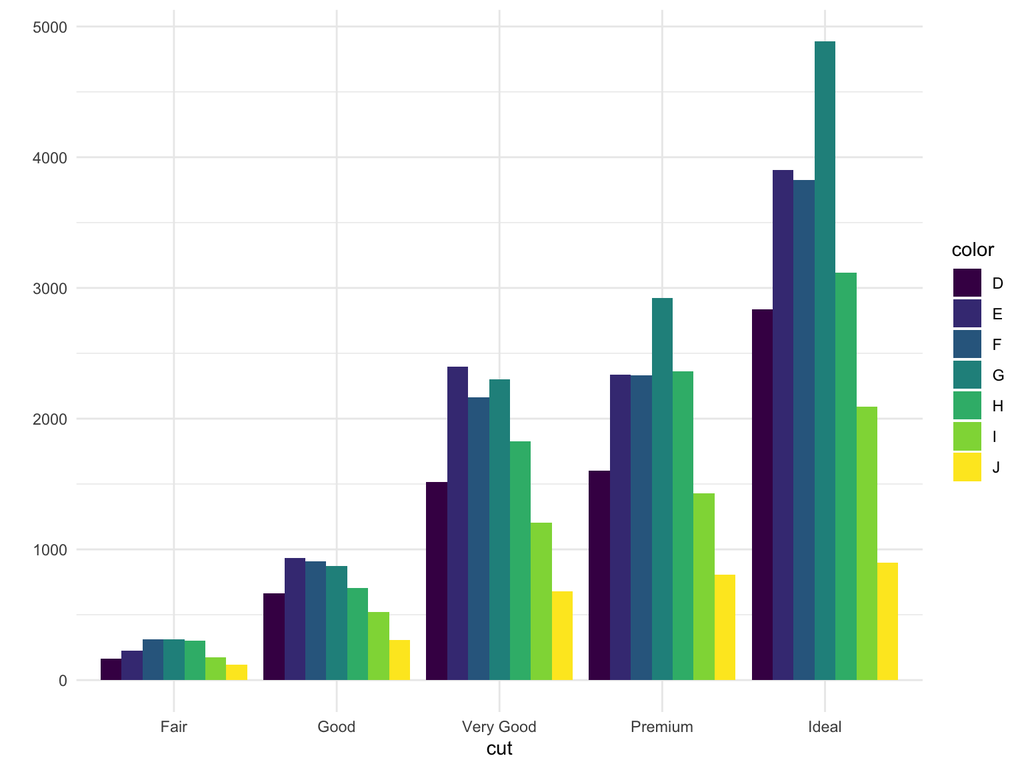

# Qualitative vs qualitative

### Exemple : Qualité et couleur

### Représentation numérique

Profils colonnes ici (sommes en colonnes = 100%)

| color | Fair | Good | Very Good | Premium | Ideal |
| --- | --- | --- | --- | --- | --- |
| D | 0.101242236024845 | 0.134936812066857 | 0.125227611322629 | 0.116235225871945 | 0.131502018467821 |
| E | 0.139130434782609 | 0.190175295556461 | 0.198642608839596 | 0.169458342397216 | 0.181105285137581 |
| F | 0.193788819875776 | 0.185283326538932 | 0.179109418970369 | 0.169023276049598 | 0.177532365087467 |
| G | 0.195031055900621 | 0.177537708927843 | 0.190283065717596 | 0.212022333405844 | 0.226625214607211 |
| H | 0.188198757763975 | 0.14309009376274 | 0.150968382718093 | 0.171126096729751 | 0.144540856572781 |
| I | 0.108695652173913 | 0.106400326131268 | 0.0996523754345307 | 0.103545790733087 | 0.0971184631803629 |
| J | 0.0739130434782609 | 0.0625764370158989 | 0.0561165369971859 | 0.0585889348125589 | 0.0415757969467774 |

### Représentation graphique

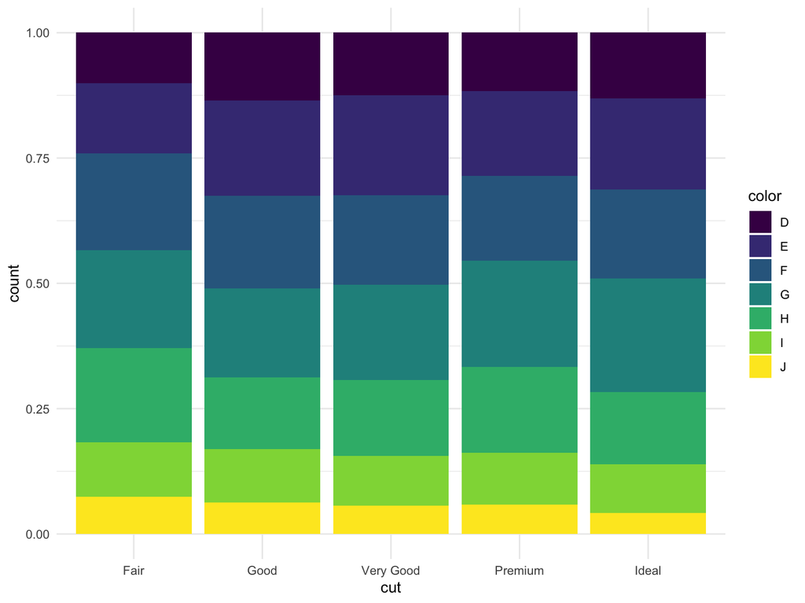

# Qualitative vs qualitative

### Exemple : Qualité et couleur

### Représentation numérique

Profils lignes ici (sommes en lignes = 100%)

| cut | Fair | Good | Very Good | Premium | Ideal |
| --- | --- | --- | --- | --- | --- |
| D | 0.0240590405904059 | 0.0977121771217712 | 0.223321033210332 | 0.236605166051661 | 0.41830258302583 |
| E | 0.0228641420843115 | 0.0952332346636725 | 0.244972950903338 | 0.238542410942125 | 0.398387261406553 |
| F | 0.0326975476839237 | 0.0952630475791239 | 0.226786837141061 | 0.244288409138545 | 0.400964158457346 |
| G | 0.0278072972015586 | 0.0771342543393553 | 0.203595465816507 | 0.258944385405597 | 0.432518597236982 |
| H | 0.0364884393063584 | 0.0845375722543353 | 0.219653179190751 | 0.284200385356455 | 0.3751204238921 |
| I | 0.0322759129472519 | 0.0962744374769458 | 0.222058281077093 | 0.263371449649576 | 0.386019918849133 |
| J | 0.0423789173789174 | 0.109330484330484 | 0.241452991452991 | 0.287749287749288 | 0.319088319088319 |

### Représentation graphique

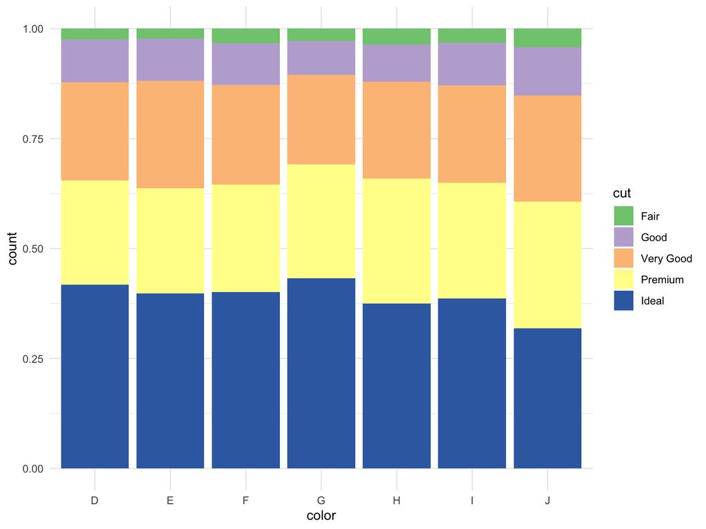

# Qualitative vs quantitative

- Soit $Y$ la variable qualitative à $m$ modalités, et $X$ la variable quantitative
- Sous-populations déterminées par les modalités de $Y$
- Indicateurs calculés pour chaque modalité
  $$\bar{x_j} = \frac{1}{n_j} \sum_{i | y_i = j} x_i$$
  $$\sigma^2(x_j) = \frac{1}{n_j} \sum_{i | y_i = j} (x_i - \bar{x_j})^2$$

# Qualitative vs quantitative

### Exemple : Qualité et prix

### Représentation numérique

| cut | Moyenne | Ecart-type |
| --- | --- | --- |
| Fair | 4358.75776397516 | 3560.3866122646 |
| Good | 3928.86445169181 | 3681.58958391557 |
| Very Good | 3981.75989074657 | 3935.86216056637 |
| Premium | 4584.25770429991 | 4349.20496149675 |
| Ideal | 3457.5419702102 | 3808.40117234901 |

A regarder aussi :

- Outliers

### Représentation graphique

Boîte à moustaches

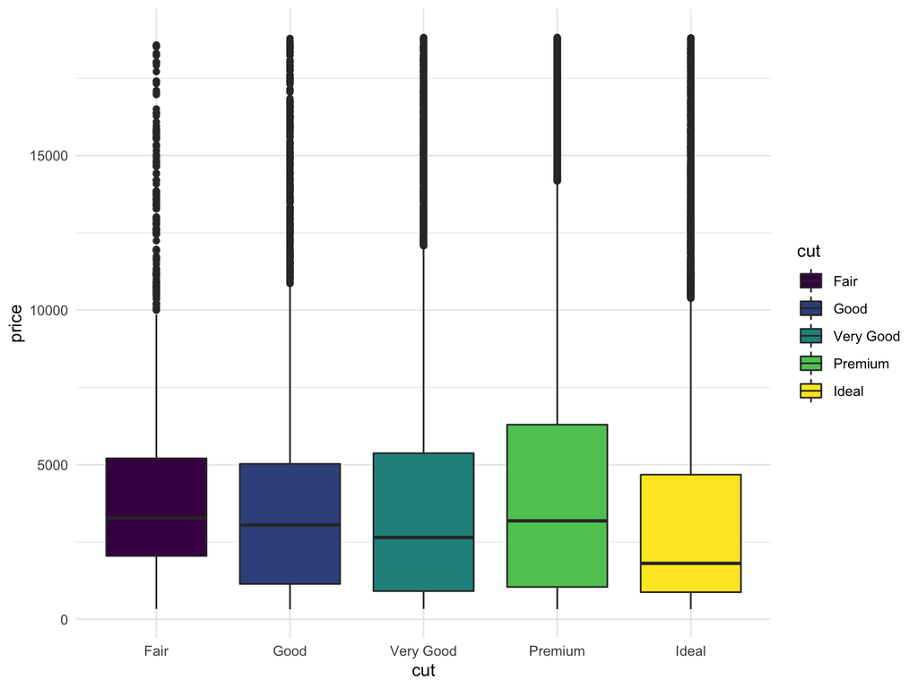

# Deuxième problème : Extrapoler à partir de données

On parle alors de **statistique inférentielle**

### Cadre

- Données issues d’un échantillon d’une population
- Modèle probabiliste sur la population
- Méthodes d’échantillonnage pour choisir au mieux l’échantillon

### Objectifs

- Etendre les conclusions faites sur l’échantillon à toute la population
- Valider (ou non) des hypothèses faites sur la population en analysant l’échantillon

### Outils

- Estimation : approximer des paramètres de la population à partir de l’échantillon
- Test : valider les hypothèses
- Modélisation : rechercher des liens entre variables, pour compréhension et prévision